# Coursera Data Science Capstone Milestone Report

## Introduction

This Milestone Report goes over the exploratory data analysis for the Capstone Project of the Data Science Specialization on Coursera

The Key partners for this project are Swiftkey and Coursera. The project explores the Natural Language Processing facet of Data Science

A large text corpus of documents to predict the next word on preceding input.

After the initial extraction and cleaning of data, it is presented on a Shiny application

This report goes over the plan on data preparation and presentation from a large corpus of text

## Load R Libraries

Libraries used for this project.

```r
library(ggplot2)
library(stringi)
library(NLP)
library(tm)
library(rJava)
library(RWekajars)
library(SnowballC)
library(RColorBrewer)
library(qdap)
library(RWeka)
library(openNLP)
```

## Load The Data

The data for this project is selected from HC Corpora

- en_US.blogs.txt
- en_US.news.txt
- en_US.twitter.txt.

The data link is provided by Coursera. After downloading the data to a local machine, it is read into R, first with an open binary connection and then creating a variable for each set

```r
blogs <- file("en_US.blogs.txt", open="rb")
blogs <- readLines(blogs, encoding = "UTF-8", skipNul=TRUE)

news <- file("en_US.news.txt", open = "rb")
news <- readLines(news, encoding = "UTF-8", skipNul=TRUE)

twitter <- file("en_US.twitter.txt", open = "rb")
twitter <- readLines(twitter, encoding = "UTF-8", skipNul=TRUE)
```

## Metadata

The loaded from each of the three files - blogs, news and twitter is now evaluated to check it’s metadata. This mainly includes the size (in megabytes), number of lines in each variable (document), number of words, length of the longest line etc.

### File Size

```r
file.info("en_US.blogs.txt")$size / 1024^2
```

```
## [1] 200.4242
```

```r
file.info("en_US.news.txt")$size  / 1024^2
```

```
## [1] 196.2775
```

```r
file.info("en_US.twitter.txt")$size / 1024^2
```

```
## [1] 159.3641
```

### Number of Lines

```r
length(blogs)
```

```
## [1] 899288
```

```r
length(news)
```

```
## [1] 1010242
```

```r
length(twitter)
```

```
## [1] 2360148
```

### Word Count

```r
sum(stri_count_words(blogs))
```

```
## [1] 37546246
```

```r
sum(stri_count_words(news))
```

```
## [1] 34762395
```

```r
sum(stri_count_words(twitter))
```

```
## [1] 30093410
```

### The length of the longest line

```r
max(nchar(blogs))
```

```
## [1] 40833
```

```r
max(nchar(news))
```

```
## [1] 11384
```

```r
max(nchar(twitter))
```

```
## [1] 140
```

## Subset The Data

These are pretty large datasets. Hence it is essential to take a small sample from the data and use the subset to going forward. Taking subsets of all three types of datasets

```r
set.seed(1234)
subTwitter <- sample(twitter, size = 5000, replace = TRUE)
subBlogs <- sample(blogs, size = 5000, replace = TRUE)
subNews <- sample(news, size = 5000, replace = TRUE)
sample <- c(subTwitter, subBlogs, subNews)
length(sample)
writeLines(sample, "./FinalData/Sample.txt")
```

[output not shown]

There are 15,000 lines in the new inclusive sample with each dataset (news, blogs, tweets) contributing 5000 lines

## Cleaning And Removing Profanity

One of the requirements of the project submission is to clean the corpus and remove any profanity in it. Several cleaning methods such as removing whitespaces, numbers, UTR and punctuations will be used

Credit: A profanity check is run using Luis von Ahn’s research group at CMU (http://www.cs.cmu.edu/~biglou/resources/).

### Clean The Data

```r
## The TM package is used to clean the corpus text
conn <- file("./finaldata/sample.txt")
corpus <- readLines(conn)
corpus <- Corpus(VectorSource(corpus))

corpus <- tm_map(corpus, content_transformer(function(x) iconv(x, to="UTF-8", sub="byte")))
corpus <- tm_map(corpus, content_transformer(tolower))
corpus <- tm_map(corpus, content_transformer(removePunctuation), preserve_intra_word_dashes=TRUE)

## Removing Profanity
profanityWords = readLines('profane_words.txt')
corpus <- tm_map(corpus,removeWords, profanityWords)

corpus <- tm_map(corpus, content_transformer(removeNumbers))

## Taking out URLs
removeURL <- function(x) gsub("http[[:alnum:]]*", "", x)
corpus <- tm_map(corpus, content_transformer(removeURL))

corpus <- tm_map(corpus, removeWords, stopwords("english"))

corpus <- tm_map(corpus, stripWhitespace)

## Save the corpus
saveRDS(corpus, file = "./FinalData/corpus.RData")
```

### Convert The Corpus To A Data Frame

```r
corpus <- readRDS("./finaldata/corpus.RData")

## Use the code below to see some lines of the corpus
##for(i in 1:10){print(finalCorpusMem[[i]]$content)}

## data framing corpus
corpus <- data.frame(text = get("content", corpus), stringsAsFactors = FALSE)
head(corpus, 50)
```

```
##                                                                                                  text
## 1                                                                   went ribbon cutting go looks nice
## 2                       time tomorrow will done nothing spend entire day relaxing beach drinking beer
## 3                                                                              dont really understand
## 4                                                                          lol fool new orleans crazy
## 5   great day remember difficulties meant rouse discourage human spirit grow strong conflict william
## 6                                             hi emilierequest acct creation current work queue soon
## 7                                                                     oh chill dont sub mood catch em
## 8                                                                       tell tweets friggen awesome d
## 9   devote great deal time talking customers person youd dazzled many companies dont listen customers
## 10                                             pull-apart monkey bread itsmagical id share photo gone
## 11                                               accurate question waited long order fri night pizza
## 12                                                               one door closes another always opens
## 13                                                                            rubbing eyes day today
## 14                                    lmao whip shape kathy griffin show tonight im trying give chuy
```

[output cut: 36 more lines]

## Tokenization

We use Tokenization to break sentences and phrases in to pairs of words or n-grams. Essentially we are breaking down units of words or tokens, hence the term tokenization.

*n*-gram is a contiguous sequence of n items from a given sequence of text or speech in Natural Language Processing (NLP). Unigrams are single words. Bigrams are two words combinations. Trigrams are three-word combinations.

We use the package RWeka for tokenization

### Obtain Unigrams

```r
unigram <- NGramTokenizer(corpus, Weka_control(min = 1, max = 1,delimiters = " \\r\\n\\t.,;:\"()?!"))
unigram <- data.frame(table(unigram))
unigram <- unigram[order(unigram$Freq,decreasing = TRUE),]

names(unigram) <- c("word1", "freq")
head(unigram)
```

```
##       word1 freq
## 27852  said 1522
## 35504  will 1324
## 22751   one 1251
## 17493  just 1153
## 18853  like 1083
## 5268    can 1028
```

```r
unigram$word1 <- as.character(unigram$word1)

write.csv(unigram[unigram$freq > 1,],"unigram.csv",row.names=F)
unigram <- read.csv("unigram.csv",stringsAsFactors = F)
saveRDS(unigram, file = "unigram.RData")
```

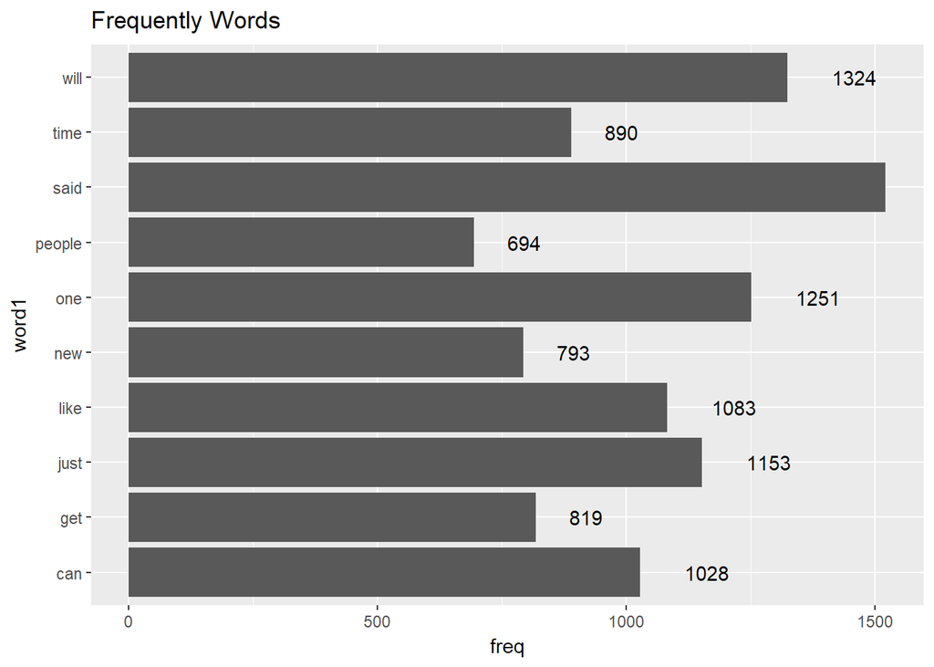

```r
unigram <- readRDS("unigram.RData")
g1 <- ggplot(data=unigram[1:10,], aes(x = word1, y = freq))
g2 <- g1 + geom_bar(stat="identity") + coord_flip() + ggtitle("Frequently Words")
g3 <- g2 + geom_text(data = unigram[1:10,], aes(x = word1, y = freq, label = freq), hjust=-1, position = "identity")
g3
```

### Obtain Bigrams

```r
bigram <- NGramTokenizer(corpus, Weka_control(min = 2, max = 2,delimiters = " \\r\\n\\t.,;:\"()?!"))
bigram <- data.frame(table(bigram))
bigram <- bigram[order(bigram$Freq,decreasing = TRUE),]
names(bigram) <- c("words","freq")
head(bigram)
```

```
##            words freq
## 100771 last year   93
## 124193  new york   85
## 155244 right now   73
## 211368 years ago   61
## 100765 last week   60
## 89214   im going   53
```

```r
bigram$words <- as.character(bigram$words)
str2 <- strsplit(bigram$words,split=" ")
bigram <- transform(bigram,
                    one = sapply(str2,"[[",1),
                    two = sapply(str2,"[[",2))
bigram <- data.frame(word1 = bigram$one,word2 = bigram$two,freq = bigram$freq,stringsAsFactors=FALSE)

names(bigram)[names(bigram) == 'word1'] <- 'w1'
names(bigram)[names(bigram) == 'word2'] <- 'w2'

write.csv(bigram[bigram$freq > 1,],"bigram.csv",row.names=F)
bigram <- read.csv("bigram.csv",stringsAsFactors = F)
saveRDS(bigram,"bigram.RData")
```

### Obtain Trigrams

```r
trigram <- NGramTokenizer(corpus, Weka_control(min = 3, max = 3,delimiters = " \\r\\n\\t.,;:\"()?!"))
trigram <- data.frame(table(trigram))
trigram <- trigram[order(trigram$Freq,decreasing = TRUE),]
names(trigram) <- c("words","freq")
head(trigram)
```

```
##                      words freq
## 216527       two years ago   14
## 31894        cant wait see   11
## 138202       new york city   10
## 193405     st louis county    9
## 10274  amazon services llc    8
## 138242      new york times    8
```

```r
trigram$words <- as.character(trigram$words)
str3 <- strsplit(trigram$words,split=" ")
trigram <- transform(trigram,
                     one = sapply(str3,"[[",1),
                     two = sapply(str3,"[[",2),
                     three = sapply(str3,"[[",3))

trigram <- data.frame(word1 = trigram$one,word2 = trigram$two,
                      word3 = trigram$three, freq = trigram$freq,stringsAsFactors=FALSE)

names(trigram)[names(trigram) == 'word1'] <- 'w1'
names(trigram)[names(trigram) == 'word2'] <- 'w2'
names(trigram)[names(trigram) == 'word3'] <- 'w3'

write.csv(trigram[trigram$freq > 1,],"trigram.csv",row.names=F)
trigram <- read.csv("trigram.csv",stringsAsFactors = F)
saveRDS(trigram,"trigram.RData")
```

### Obtain Quadgrams

```r
quadgram <- NGramTokenizer(corpus, Weka_control(min = 4, max = 4,delimiters = " \\r\\n\\t.,;:\"()?!"))
quadgram <- data.frame(table(quadgram))
quadgram <- quadgram[order(quadgram$Freq,decreasing = TRUE),]

names(quadgram) <- c("words","freq")
head(quadgram)
```

```
##                                        words freq
## 54007                  dhs cedar rapids iowa    7
## 647                    -footer th -footer th    4
## 2847                        subject change    4
## 3807                 subject change removal    4
## 6533    advertising fees advertising linking    4
## 6539  advertising linking amazoncom amazonca    4
```

```r
quadgram$words <- as.character(quadgram$words)

str4 <- strsplit(quadgram$words,split=" ")
quadgram <- transform(quadgram,
                      one = sapply(str4,"[[",1),
                      two = sapply(str4,"[[",2),
                      three = sapply(str4,"[[",3),
                      four = sapply(str4,"[[",4))

quadgram <- data.frame(word1 = quadgram$one,
                       word2 = quadgram$two,
                       word3 = quadgram$three,
                       word4 = quadgram$four,
                       freq = quadgram$freq, stringsAsFactors=FALSE)

names(quadgram)[names(quadgram) == 'word1'] <- 'w1'
names(quadgram)[names(quadgram) == 'word2'] <- 'w2'
names(quadgram)[names(quadgram) == 'word3'] <- 'w3'
names(quadgram)[names(quadgram) == 'word4'] <- 'w4'

write.csv(quadgram[quadgram$freq > 1,],"quadgram.csv",row.names=F)
quadgram <- read.csv("quadgram.csv",stringsAsFactors = F)
saveRDS(quadgram,"quadgram.RData")
```

## Next Steps

*NLP is a resource intensive process and hence we focus on a small subset of the actual data to build the corpus* We then use this corpus to build n-grams using Tokenization *At the end of tokenization process we have bigrams, trigrams and quadgrams* We will use these sets of n-grams to create predictive model *We will also build a Shiny app as a user-interface to interact with our predictive models to predict the next word* We will also have a slide-deck ready to present and publish our app to general audience